# Part 1 - The Crime Analysis Overview

As Sedjaoui (2018, p.33) explains, ‘big data is the revolutionary word in today’s world because of its influence on several domains.’ This can range from government bodies to businesses trying to find the edge over their competitors. In this context, we will be using government provided data to explore claims made by the Ross Kemp documentary. The media likewise in 2019 appeared to agree with some of the statements with the BBC reporting that ‘Violent Crime recorded by police rises by 19%’ (BBC, 2019).

The aim of this report is to substantiate the many claims that were made in the aforementioned documentary. Whilst generic statements such as ‘Violent crime is increasing’ or ‘Crimes involving firearms are closely associated with drug offences’ are easy to digest for the general public, they may not tell the wider picture that the data shows. For example, is violent crime showing seasonal changes or is there no correlation? How strong is the relationship between crimes involving firearms and drug offences? As Hodeghatta and Nayak (2023, ch.1, section. 1.6) state, ‘having only programming skills along with statistical or mathematical knowledge can sometimes lead to proposing impractical suggestions.’ Therefore, I will use a carefully planned journey to validate the above claims.

Throughout this process, I will be using Apache Sparks through Azure IAAS to analyse the big data sets I have selected – Street Level Crime Data and LSOA_POP (population dataset). Through testing, I found that loading the data into Jupyter was quicker than via Blob Storage so will therefore be the method I choose. Once the dataset has been loaded, I will be using RDDs to initially filter the data. This will be violent crimes, drug offences, and I will be filtering the population data set to contain a sum of all the residents in a certain area. Like above, I found this quicker than if the data was loaded straight into a dataframe. These steps will be achieved through created functions.

From there, I will use a range of visualisations to attribute a pictorial representation of the different relationships. However, simple presenting this isn’t sufficient – as Nudurupari (2021, loc 189) explains, ‘the process of translating data into a pictorial representation (data visualisation)’ …’ makes it easier for the human mind to comprehend complex information’. Whilst this is true, it is important that machine learning models and statistics are both used as well to connect a numerical value that can show the strength of relationships. Once all these steps have been taken, I will then explain from my point of view the results of the analysis to highlight the degree to which I agree or disagree with the above claims.

# Part 2 Component Selection and Data Pipeline Implementation

```python
import numpy as np
import pandas as pd
import matplotlib.pyplot as plt

import warnings
warnings.filterwarnings("ignore")
import itertools

from pyspark import SparkFiles
from pyspark.sql import SparkSession
from pyspark.sql.types import *
from pyspark.sql.functions import count, udf, avg, sum, col, to_date
from pyspark.sql import functions as F
from pyspark.sql import Row

from pyspark.ml.linalg import Vectors
from pyspark.ml.stat import Correlation
from pyspark.ml import Pipeline
from pyspark.ml.feature import VectorAssembler
from pyspark.ml.regression import LinearRegression
from pyspark.ml.evaluation import RegressionEvaluator
from pyspark.ml.evaluation import ClusteringEvaluator
from pyspark.ml.clustering import KMeans
from pyspark.ml.feature import VectorAssembler

from statsmodels.tsa.stattools import adfuller
import statsmodels.api as sm

from sklearn import metrics

import seaborn as sns; sns.set_theme()
```

```python
spark = SparkSession\
.builder\
.appName("Assignment")\
.getOrCreate()

sc = spark.sparkContext
sc
```

**SparkContext**

[Spark UI](http://0085a7b84dcb:4040)

**Version**

`v3.1.2`

**Master**

`local[*]`

**AppName**

`Assignment`

```python
text_rdd = sc.textFile("all_crimes21_assignment.txt.gz")
```

```python
%%time

text_rdd.count()
```

```
CPU times: user 9.62 ms, sys: 11.1 ms, total: 20.7 ms
Wall time: 1min 42s
```

```
65078251
```

# Part 3 - Data Extraction and Filtering

Next, I will create a series of functions which will be passed to the text_rdd to filter down the different crimes needed. At this stage, I will not be filtering by date as I found combining that with the text filter at this stage increased the time to create the filtered RDD. The reason I will be eventually filtering by date is the fact that the documentary was released in September 2018. I therefore want to substantiate the claims made based on the data available at the time of recording. Moreover, post 2018 the coronavirus lockdowns would likely affect crime rates due to the ‘Stay at home’ message.

It is important to note that circa April 2013, the tag in the ‘Crime Type’ field was renamed to ‘Violence and Sexual Offences’. Therefore, both tags have been included in the function through an ‘or’ clause.

As determined in the specification, a ‘firearm incident’ is being categorised with a ‘Crime Type’ of ‘Possession of Weapons’ and an outcome of ‘Offender sent to prison’. Therefore an ‘and’ clause has been used to filter the data for this RDD.

I have finally created a ‘remove_after_last_space’ function. This will remove anything after a location name in the population dataset. For example, ‘Birmingham 003A’ will simply return ‘Birmingham’ to allow for clear analysis of claim 2 – ‘There are more firearm incidents per head in Birmingham than anywhere else in the UK.’ This will only be applied on the dataframe in the specific column related to a location (LSOA Name).

```python
def contains_violent_crimes(line):
    line_lower = line.lower()
    return "violent crime" in line_lower or "violence and sexual offences" in line_lower

def contains_firearm_incidents(line):
    line_lower = line.lower()
    return "possession of weapons" in line_lower and "offender sent to prison" in line_lower

def contains_drug_incidents(line):
    line_lower = line.lower()
    return "drugs" in line.lower()

def remove_after_last_space(value):
    if not value:
        return "No Location Given"
    return value.rsplit(' ', 1)[0]

remove_space_udf = udf(remove_after_last_space, StringType())
```

```python
violent_crimes_rdd = text_rdd.filter(contains_violent_crimes)
```

```python
%%time

vc_occurences = violent_crimes_rdd.count()

print(vc_occurences)
```

```
13084759
CPU times: user 10.5 ms, sys: 880 µs, total: 11.4 ms
Wall time: 1min 41s
```

```python
%%time

violent_crimes_rdd.saveAsTextFile("violent_crimes.txt")
```

```
CPU times: user 10 ms, sys: 504 µs, total: 10.5 ms
Wall time: 2min 1s
```

```python
firearms_rdd = text_rdd.filter(contains_firearm_incidents)
```

```python
%%time

fa_occurences = firearms_rdd.count()

print(fa_occurences)
```

```
10416
CPU times: user 11.4 ms, sys: 0 ns, total: 11.4 ms
Wall time: 1min 34s
```

```python
%%time

firearms_rdd.saveAsTextFile("firearm_incidents.txt")
```

```
CPU times: user 4.85 ms, sys: 4.4 ms, total: 9.25 ms
Wall time: 1min 34s
```

```python
drugs_rdd = text_rdd.filter(contains_drug_incidents)
```

```python
%%time

d_occurences = drugs_rdd.count()

print(d_occurences)
```

```
1691189
CPU times: user 9.53 ms, sys: 812 µs, total: 10.3 ms
Wall time: 1min 46s
```

```python
%%time

drugs_rdd.saveAsTextFile("drug_incidents.txt")
```

```
CPU times: user 5.53 ms, sys: 4.16 ms, total: 9.69 ms
Wall time: 1min 48s
```

```python
!ls
```

```
 LSOA_pop_v2.csv		  drug_incidents.txt
 all_crimes21_assignment.txt.gz   firearm_incidents.txt
 assignment.ipynb		  violent_crimes.txt
'deprivation_with_hdr (1).gz'
```

When loading the data into datframes, I created my own schemas to use throughout to ensure consistency.

```python
crime_schema = StructType(
    [StructField("CrimeID",StringType(),True),
     StructField("MonthYear",StringType(),True),
     StructField("ReportedBy",StringType(),True),
     StructField("FallsWithin",StringType(),True),
     StructField("Longitude",DoubleType(),True),
     StructField("Latitude",DoubleType(),True),
     StructField("Location",StringType(),True),
     StructField("LSOACode",StringType(),True),
     StructField("LSOAName",StringType(),True),
     StructField("CrimeType",StringType(),True),
     StructField("LastOutcome",StringType(),True),
     StructField("Context",StringType(),True)])
```

```python
population_schema = StructType(
    [StructField("Date",IntegerType(),True),
     StructField("Geography",StringType(),True),
     StructField("GeographyCode",StringType(),True),
     StructField("RuralUrban",StringType(),True),
     StructField("AllResidents",IntegerType(),True),
     StructField("MaleResidents",IntegerType(),True),
     StructField("FemaleResidents",IntegerType(),True),
     StructField("HouseholdResidents",IntegerType(),True),
     StructField("CommunalResidents",IntegerType(),True),
     StructField("Students",IntegerType(),True),
     StructField("Area",DoubleType(),True),
     StructField("Density",DoubleType(),True)])
```

```python
deprivation_schema = StructType(
    [StructField("LSOACode",StringType(),True),
     StructField("LSOAName",StringType(),True),
     StructField("IMDRank",IntegerType(),True),
     StructField("IncomeRank",IntegerType(),True),
     StructField("EmploymentRank",IntegerType(),True)])
```

Part 3 - Claim 1 - Data Extraction - Extracting the data by MonthYear

```python
%%time

v_df = spark.read.csv("violent_crimes.txt", header = False, inferSchema = True)
```

```
CPU times: user 2.89 ms, sys: 0 ns, total: 2.89 ms
Wall time: 17.9 s
```

```python
%%time

violent_crime_df = spark.createDataFrame(v_df.rdd,schema = crime_schema) #reloads the dataframe with the above schema.
```

```
CPU times: user 5.91 ms, sys: 3.8 ms, total: 9.71 ms
Wall time: 291 ms
```

```python
violent_crime_df.printSchema() # shows this has been properly loaded.
```

```
root
 |-- CrimeID: string (nullable = true)
 |-- MonthYear: string (nullable = true)
 |-- ReportedBy: string (nullable = true)
 |-- FallsWithin: string (nullable = true)
 |-- Longitude: double (nullable = true)
 |-- Latitude: double (nullable = true)
 |-- Location: string (nullable = true)
 |-- LSOACode: string (nullable = true)
 |-- LSOAName: string (nullable = true)
 |-- CrimeType: string (nullable = true)
 |-- LastOutcome: string (nullable = true)
 |-- Context: string (nullable = true)
```

```python
#The further filtration now takes place to take into account September 2018 and before.
vc_df = (violent_crime_df
        .select("MonthYear", "CrimeType")
        .where(violent_crime_df.MonthYear < "2018-10")
        .groupBy("MonthYear")
        .agg(count("CrimeType").alias("Total"))
        .orderBy("MonthYear"))
```

```python
%%time

#Turns the violent crime dataframe to a pandas dataframe to allow for timeseries creation and analysis.
#The data is now ready be visualised and analysed in the later sections.

tsdf = vc_df.toPandas()
```

```
CPU times: user 38.5 ms, sys: 16.9 ms, total: 55.5 ms
Wall time: 2min 10s
```

```python
%%time

f_df = spark.read.csv("firearm_incidents.txt", header = False, inferSchema = True)
```

```
CPU times: user 0 ns, sys: 2.1 ms, total: 2.1 ms
Wall time: 206 ms
```

```python
%%time

firearm_df = spark.createDataFrame(f_df.rdd,schema = crime_schema)
```

```
CPU times: user 7.25 ms, sys: 301 µs, total: 7.55 ms
Wall time: 54 ms
```

```python
%%time

firearm_df.count()
```

```
CPU times: user 1.53 ms, sys: 0 ns, total: 1.53 ms
Wall time: 316 ms
```

```
10416
```

```python
firearm_df = firearm_df.withColumn("LSOAName", remove_space_udf(col("LSOAName")))
```

```python
%%time

firearms_df = (firearm_df
            .select("*")
            .where(firearm_df.MonthYear < '2018-10')
            .groupBy("LSOAName")
            .agg(count("CrimeType").alias("Total"))
            .orderBy(col("Total").desc()))
```

```
CPU times: user 5.2 ms, sys: 0 ns, total: 5.2 ms
Wall time: 48.7 ms
```

```python
%%time

firearms_df.show()
```

```
+------------------+-----+
|          LSOAName|Total|
+------------------+-----+
| No Location Given|  274|
|        Birmingham|  220|
|             Leeds|  189|
|         Liverpool|  161|
|         Sheffield|  144|
|        Nottingham|  139|
|           Lambeth|  132|
|        Manchester|  128|
|             Derby|  124|
|       Westminster|  117|
|          Bradford|  110|
|Kingston upon Hull|  107|
|         Doncaster|  104|
|    Stoke-on-Trent|  102|
|          Plymouth|   99|
|           Cardiff|   95|
|     County Durham|   93|
|     Tower Hamlets|   93|
|            Newham|   92|
|           Croydon|   92|
+------------------+-----+
only showing top 20 rows

CPU times: user 6.46 ms, sys: 8.13 ms, total: 14.6 ms
Wall time: 1.23 s
```

```python
%%time

pop_df = spark.read.csv("LSOA_pop.csv",header=True,inferSchema=True)
```

```
CPU times: user 0 ns, sys: 2.61 ms, total: 2.61 ms
Wall time: 299 ms
```

```python
population_df = spark.createDataFrame(pop_df.rdd, schema = population_schema)
```

```python
population_df = population_df.withColumn("Geography", remove_space_udf(col("Geography")))
```

```python
%%time

population_df = (population_df
         .select("Geography", "AllResidents")
         .groupBy("Geography")
         .agg(sum("AllResidents").alias("Total"))
         .orderBy(col("Total").desc()))
```

```
CPU times: user 4.17 ms, sys: 443 µs, total: 4.62 ms
Wall time: 34 ms
```

```python
%%time

population_df.show()
```

```
+--------------------+-------+
|           Geography|  Total|
+--------------------+-------+
|          Birmingham|1073045|
|               Leeds| 751485|
|           Sheffield| 552698|
|            Cornwall| 532273|
|            Bradford| 522452|
|       County Durham| 513242|
|          Manchester| 503127|
|           Wiltshire| 470981|
|           Liverpool| 466415|
|             Bristol| 428234|
|            Kirklees| 422458|
|       Cheshire East| 370127|
|             Croydon| 363378|
|              Barnet| 356386|
|             Cardiff| 346090|
|              Ealing| 338449|
|East Riding of Yo...| 334179|
|           Leicester| 329839|
|Cheshire West and...| 329608|
|           Wakefield| 325837|
+--------------------+-------+
only showing top 20 rows

CPU times: user 8.14 ms, sys: 8.42 ms, total: 16.6 ms
Wall time: 1.68 s
```

```python
population_df.createOrReplaceTempView("population")
firearms_df.createOrReplaceTempView("firearm_totals")
```

```python
%%time

all_areas_result = spark.sql("""SELECT p.Geography,
ROUND((f.Total / p.Total) * 5000,4) AS firearm_incidents_per_5000_people
FROM population p
INNER JOIN firearm_totals f ON p.Geography = f.LSOAName
ORDER BY firearm_incidents_per_5000_people DESC""")
```

```
CPU times: user 1.61 ms, sys: 0 ns, total: 1.61 ms
Wall time: 108 ms
```

```python
%%time

all_areas_result.show()
```

```
+------------------+---------------------------------+
|         Geography|firearm_incidents_per_5000_people|
+------------------+---------------------------------+
|    City of London|                          11.5254|
|       Westminster|                           2.6664|
|             Derby|                           2.4924|
|        Nottingham|                           2.2736|
|           Lambeth|                           2.1776|
|Kingston upon Hull|                           2.0865|
|        Darlington|                            2.084|
|           Norwich|                           2.0753|
|    Stoke-on-Trent|                           2.0481|
|         Islington|                           2.0133|
|           Watford|                           1.9933|
|            Thanet|                           1.9376|
|          Plymouth|                           1.9307|
|       Scarborough|                           1.9303|
|           Lincoln|                           1.9243|
|            Torbay|                            1.909|
|            Boston|                           1.8565|
|     Tower Hamlets|                             1.83|
|          Haringey|                           1.7848|
|         Worcester|                           1.7718|
+------------------+---------------------------------+
only showing top 20 rows

CPU times: user 15.5 ms, sys: 270 µs, total: 15.8 ms
Wall time: 2.48 s
```

```python
df = spark.read.csv("deprivation.gz",header=True,inferSchema=True)
```

```python
deprivation_df = df.select("LSOA CODE", "PRE 2009 LA NAME", "RANK OF IMD SCORE (where 1 is most deprived)", "RANK OF INCOME SCORE (where 1 is most deprived)", "RANK OF EMPLOYMENT SCORE (where 1 is most deprived)")
```

```python
deprivation_df = spark.createDataFrame(deprivation_df.rdd, schema = deprivation_schema)
```

```python
%%time

deprivation_df.show()
```

```
+---------+--------------------+-------+----------+--------------+
| LSOACode|            LSOAName|IMDRank|IncomeRank|EmploymentRank|
+---------+--------------------+-------+----------+--------------+
|E01000001|      City of London|  28814|     32460|         32435|
|E01000002|      City of London|  29450|     32457|         32452|
|E01000003|      City of London|  20047|     22562|         26026|
|E01000004|      City of London|  22503|     30002|         28814|
|E01000005|      City of London|  12978|     11341|         19427|
|E01000006|Barking and Dagenham|  16410|     14996|         20979|
|E01000007|Barking and Dagenham|   5438|      5053|         12409|
|E01000008|Barking and Dagenham|   3172|      1145|          7055|
|E01000009|Barking and Dagenham|   8462|      8499|         11184|
|E01000010|Barking and Dagenham|   5038|      3207|          9636|
|E01000011|Barking and Dagenham|   8421|      6609|         12377|
|E01000012|Barking and Dagenham|   5400|      2859|         12485|
|E01000013|Barking and Dagenham|   4626|      4537|          7874|
|E01000014|Barking and Dagenham|   5235|      4482|          6273|
|E01000015|Barking and Dagenham|   4926|      2631|          7467|
|E01000016|Barking and Dagenham|   7495|      6671|          8336|
|E01000017|Barking and Dagenham|   6099|      4153|          6752|
|E01000018|Barking and Dagenham|   7073|      5788|          7898|
|E01000019|Barking and Dagenham|   6993|      4654|          9267|
|E01000020|Barking and Dagenham|   6486|      5412|          7821|
+---------+--------------------+-------+----------+--------------+
only showing top 20 rows

CPU times: user 1.54 ms, sys: 167 µs, total: 1.71 ms
Wall time: 187 ms
```

```python
deprivation_df.createOrReplaceTempView("deprivation")
```

```python
%%time

dep_grouped = spark.sql(""" SELECT LSOAName, ROUND(AVG(IMDRank)) AS AvgIMDRank, ROUND(AVG(IncomeRank)) AS AvgIncomeRank,
ROUND(AVG(EmploymentRank)) AS AvgEmploymentRank
FROM deprivation d
GROUP BY LSOAName;""")
```

```
CPU times: user 1.27 ms, sys: 0 ns, total: 1.27 ms
Wall time: 34.1 ms
```

```python
%%time

dep_grouped.show()
```

```
+---------------+----------+-------------+-----------------+
|       LSOAName|AvgIMDRank|AvgIncomeRank|AvgEmploymentRank|
+---------------+----------+-------------+-----------------+
|North Wiltshire|   24238.0|      22326.0|          23405.0|
|      Worcester|   17127.0|      17401.0|          17334.0|
|      Charnwood|   21703.0|      20961.0|          21796.0|
| North Kesteven|   23582.0|      21053.0|          20663.0|
|  Epping Forest|   20255.0|      19010.0|          21181.0|
|        Waveney|   14797.0|      13938.0|          12983.0|
|           Arun|   17074.0|      17644.0|          17363.0|
| North Cornwall|   12879.0|      15021.0|          15260.0|
|         Stroud|   22780.0|      20518.0|          20621.0|
|         Maldon|   21403.0|      19365.0|          21156.0|
|     New Forest|   23267.0|      21458.0|          22396.0|
|      Sedgemoor|   16870.0|      17248.0|          15909.0|
|St. Edmundsbury|   20829.0|      20571.0|          20905.0|
|      Guildford|   25214.0|      24603.0|          26085.0|
|       Worthing|   17904.0|      18149.0|          16487.0|
|        Fareham|   26619.0|      24705.0|          25306.0|
|         Bolton|   11820.0|      13275.0|          10617.0|
| North Tyneside|   15596.0|      14692.0|          12155.0|
| Wellingborough|   16213.0|      16773.0|          16309.0|
|   Surrey Heath|   27616.0|      25782.0|          27899.0|
+---------------+----------+-------------+-----------------+
only showing top 20 rows

CPU times: user 3.22 ms, sys: 0 ns, total: 3.22 ms
Wall time: 791 ms
```

```python
all_areas_result.createOrReplaceTempView("firearm_crimes")
dep_grouped.createOrReplaceTempView("deprivation")
```

```python
%%time

complete_claim2 = spark.sql("""SELECT f.Geography, f.firearm_incidents_per_5000_people, d.LSOAName, d.AvgIMDRank,
d.AvgIncomeRank,d.AvgEmploymentRank FROM firearm_crimes f
INNER JOIN deprivation d ON f.Geography = d.LSOAName
ORDER BY f.firearm_incidents_per_5000_people DESC""")
```

```
CPU times: user 1.39 ms, sys: 24 µs, total: 1.41 ms
Wall time: 12 ms
```

```python
%%time

complete_claim2.show()
```

```
+--------------+---------------------------------+--------------+----------+-------------+-----------------+
|     Geography|firearm_incidents_per_5000_people|      LSOAName|AvgIMDRank|AvgIncomeRank|AvgEmploymentRank|
+--------------+---------------------------------+--------------+----------+-------------+-----------------+
|City of London|                          11.5254|City of London|   22758.0|      25764.0|          27831.0|
|   Westminster|                           2.6664|   Westminster|   13103.0|      16497.0|          19385.0|
|         Derby|                           2.4924|         Derby|   14924.0|      14554.0|          13693.0|
|    Nottingham|                           2.2736|    Nottingham|    8379.0|       9914.0|          10283.0|
|       Lambeth|                           2.1776|       Lambeth|    8403.0|       9135.0|          12077.0|
|    Darlington|                            2.084|    Darlington|   13939.0|      14533.0|          11468.0|
|       Norwich|                           2.0753|       Norwich|   12721.0|      12755.0|          13114.0|
|Stoke-on-Trent|                           2.0481|Stoke-on-Trent|    8781.0|      10941.0|           7094.0|
|     Islington|                           2.0133|     Islington|    6591.0|       6643.0|           8910.0|
|       Watford|                           1.9933|       Watford|   19302.0|      18675.0|          21251.0|
|        Thanet|                           1.9376|        Thanet|   11777.0|      11021.0|          10345.0|
|      Plymouth|                           1.9307|      Plymouth|   13225.0|      15011.0|          13129.0|
|   Scarborough|                           1.9303|   Scarborough|   13463.0|      14242.0|          12503.0|
|       Lincoln|                           1.9243|       Lincoln|   12404.0|      13484.0|          12724.0|
|        Torbay|                            1.909|        Torbay|   11915.0|      11445.0|           9458.0|
|        Boston|                           1.8565|        Boston|   12855.0|      14085.0|          11493.0|
| Tower Hamlets|                             1.83| Tower Hamlets|    5785.0|       4714.0|          10584.0|
|      Haringey|                           1.7848|      Haringey|    7329.0|       7766.0|          11209.0|
|     Worcester|                           1.7718|     Worcester|   17127.0|      17401.0|          17334.0|
|       Hackney|                           1.7461|       Hackney|    4232.0|       4200.0|           7708.0|
+--------------+---------------------------------+--------------+----------+-------------+-----------------+
only showing top 20 rows

CPU times: user 4.33 ms, sys: 11.6 ms, total: 15.9 ms
Wall time: 2.64 s
```

I have then created a new query to show the top 50 to display in the bar chart more appropriately.

```python
%%time

complete_claim2_top50 = spark.sql("""SELECT f.Geography, f.firearm_incidents_per_5000_people, d.LSOAName, d.AvgIMDRank,
d.AvgIncomeRank,d.AvgEmploymentRank FROM firearm_crimes f
INNER JOIN deprivation d ON f.Geography = d.LSOAName
ORDER BY f.firearm_incidents_per_5000_people DESC
LIMIT 50""")
```

```
CPU times: user 1.48 ms, sys: 164 µs, total: 1.64 ms
Wall time: 17.7 ms
```

Part 3 - Claim 3 Data Extraction - Extracting the drug offences. The violent crimes df can be used from above.

```python
%%time

drug_df = spark.read.csv("drug_incidents.txt", header = False, inferSchema = True)
```

```
CPU times: user 2.57 ms, sys: 60 µs, total: 2.63 ms
Wall time: 1.86 s
```

```python
drugs_df = spark.createDataFrame(drug_df.rdd,schema = crime_schema)
```

```python
drugs_df = drugs_df.withColumn("LSOAName", remove_space_udf(col("LSOAName")))
```

```python
drug_df = (drugs_df
         .select("LSOAName", "CrimeType")
         .groupBy("LSOAName")
         .agg(count("CrimeType").alias("Total"))
         .orderBy(col("Total").desc()))
```

```python
%%time

drug_df.show()
```

```
+-----------------+------+
|         LSOAName| Total|
+-----------------+------+
|No Location Given|101550|
|        Liverpool| 47201|
|      Westminster| 28499|
|       Birmingham| 28425|
|            Leeds| 24494|
|    Tower Hamlets| 21886|
|            Brent| 21841|
|        Southwark| 21232|
|          Lambeth| 21136|
|       Nottingham| 19743|
|           Newham| 19522|
|          Croydon| 18643|
|           Camden| 17065|
|       Manchester| 17017|
|          Cardiff| 15992|
|         Bradford| 15867|
|           Ealing| 14778|
|           Sefton| 14208|
|          Hackney| 14125|
|         Lewisham| 13217|
+-----------------+------+
only showing top 20 rows

CPU times: user 11.9 ms, sys: 3.54 ms, total: 15.4 ms
Wall time: 19.9 s
```

```python
drug_df.createOrReplaceTempView("drugs_total")
firearms_df.createOrReplaceTempView("firearm_total")
```

```python
combined = spark.sql("""SELECT d.LSOAName, d.Total AS drug_count, f.Total AS firearm_count FROM drugs_total d
INNER JOIN firearm_total f ON d.LSOAName = f.LSOAName
ORDER BY d.Total DESC""")
```

```python
%%time

combined.show()
```

```
+-----------------+----------+-------------+
|         LSOAName|drug_count|firearm_count|
+-----------------+----------+-------------+
|No Location Given|    101550|          274|
|        Liverpool|     47201|          161|
|      Westminster|     28499|          117|
|       Birmingham|     28425|          220|
|            Leeds|     24494|          189|
|    Tower Hamlets|     21886|           93|
|            Brent|     21841|           81|
|        Southwark|     21232|           87|
|          Lambeth|     21136|          132|
|       Nottingham|     19743|          139|
|           Newham|     19522|           92|
|          Croydon|     18643|           92|
|           Camden|     17065|           38|
|       Manchester|     17017|          128|
|          Cardiff|     15992|           95|
|         Bradford|     15867|          110|
|           Ealing|     14778|           69|
|           Sefton|     14208|           43|
|          Hackney|     14125|           86|
|         Lewisham|     13217|           88|
+-----------------+----------+-------------+
only showing top 20 rows

CPU times: user 5.84 ms, sys: 8.66 ms, total: 14.5 ms
Wall time: 23 s
```

# Part 4 - Design, Development and reasoning behind use of multiple visualization methods, statistics, and machine learning Models

Claim 1

When completing data visualisations for the first claim, I will be plotting the data as a timeseries to explore the changes in the data over time. Initially, I will be able to see if there is an upward, downward or lack of trend. From there, I will complete a seasonal decomposition which will highlight the trend, seasonal changes and any residual changes. It is worth noting that because the data is grouped by month, there will only be 12 plots per year. As Nielsen (2019) explains, 'with low sample size, false positives for unit roots are fairly common' and is something that should be considered when applying the resultant data to the machine learning model.

```python
tsdf.MonthYear = tsdf.MonthYear.astype('datetime64[ns]')
tsdf2 = tsdf.set_index(pd.to_datetime(tsdf.MonthYear)) # ensures the date format
```

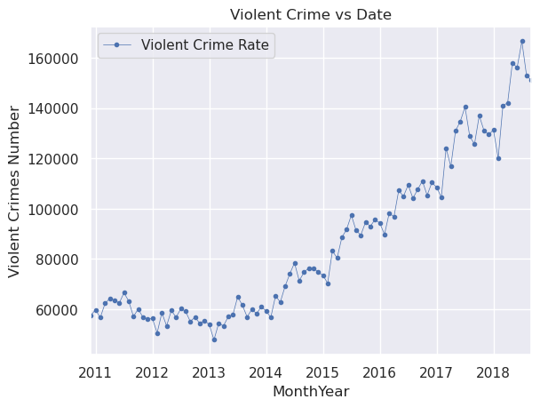

```python
tsdf2.plot(y='Total', x = 'MonthYear', marker = '.', linestyle = '-',
           linewidth = 0.5,subplots = False, label = 'Violent Crime Rate', title = 'Violent Crime vs Date')
plt.ylabel('Violent Crimes Number')
plt.show() #plots the violent crime data
```

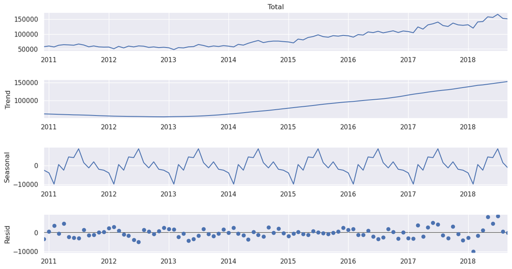

```python
decomposition = sm.tsa.seasonal_decompose(tsdf2['Total'], model = 'additive', extrapolate_trend = 'freq')
fig = decomposition.plot()
fig.set_size_inches(14,7)
plt.show()
```

As seen from the above plot, there is a clear upward trend for violent crimes. However, it is worth remembering that the tag changed in circa April 2013 to 'Violence and sexual offences'. Questions could be asked about how data was reported before April 2013 in relation to sexual offences as this could have been under the 'Other crime' tag used during this time. This could be one explanation of the mostly upward trend of the above plot from this point onwards.

Despite this, there are seasonal changes occurring on a year by year basis. There are clear peaks in the summer months, especially in the summer of 2018. This can likely be attributed to the weather, people spending more time outdoors and large amounts of alcohol being consumed. There are various reports and articles linking the above such as by Dearden (2022) who interviewed a PCC explaining that with ‘people outside, you’ve got barbecues, street parties, people consuming more alcohol, spilling outside pubs and clubs. You are naturally going to see a crime spike and the hotter the weather gets the worse it is.’ Hambling’s (2019) article further substantiates this theory after exploring studies relating to temperature and violent crimes determining that ‘High temperatures make people more impulsive, and violent acts get committed literally in the heat of the moment’.

It is also worth noting the peak of Summer 2018 - this was during the 2018 World Cup in which England reached the semi-finals. Again, this can show a cause and effect relationship for the spike at this point – as the CPS (2022) explored ‘Data showed reported incidents increased by 26 percent if England play, 38 percent if England lose, and 11 percent the next day, win or lose’.

```python
def test_stationarity(timeseries, title): #stationarity function to be executed.
    plt.clf()
    rolmean = pd.Series(timeseries).rolling(window=12).mean()
    rolstd = pd.Series(timeseries).rolling(window=12).std()

    fig, ax = plt.subplots(figsize=(16, 4))
    ax.plot(timeseries, label= title)
    ax.plot(rolmean, label='rolling mean');
    ax.plot(rolstd, label='rolling std (x10)');
    ax.legend()
    plt.show()
```

```python
def ADF_test(timeseries, dataDesc):
    print(' > Is the {} stationary ?'.format(dataDesc))
    dftest = adfuller(timeseries.dropna(), autolag='AIC')
    print('Test statistic = {:.3f}'.format(dftest[0]))
    print('P-value = {:.3f}'.format(dftest[1]))
    print('Critical values :')
    for k, v in dftest[4].items():
        print('\t{}: {} - The data is {} stationary with {}% confidence'.format(k, v, 'not' if v<dftest[0] else '', 100-int(k[:-1])))
```

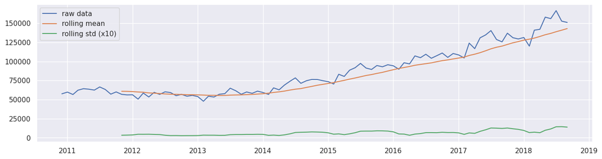

```
 > Is the raw data stationary ?
Test statistic = 1.248
P-value = 0.996
Critical values :
	1%: -3.5137900174243235 - The data is not stationary with 99% confidence
	5%: -2.8979433868293945 - The data is not stationary with 95% confidence
	10%: -2.5861907285474777 - The data is not stationary with 90% confidence
```

```python
pd.options.display.float_format = '{:.8f}'.format #tests the raw data
test_stationarity(tsdf2['Total'],'raw data')
ADF_test(tsdf2['Total'],'raw data')
```

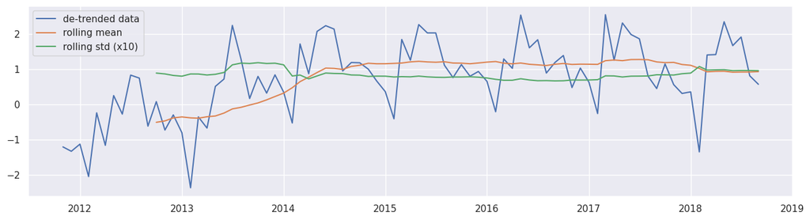

```
 > Is the de-trended data stationary ?
Test statistic = -2.353
P-value = 0.156
Critical values :
	1%: -3.5274258688046647 - The data is not stationary with 99% confidence
	5%: -2.903810816326531 - The data is not stationary with 95% confidence
	10%: -2.5893204081632653 - The data is not stationary with 90% confidence
```

```python
y = tsdf2['Total']
y_detrend =  (y - y.rolling(window=12).mean())/y.rolling(window=12).std()

test_stationarity(y_detrend,'de-trended data')
ADF_test(y_detrend,'de-trended data')
```

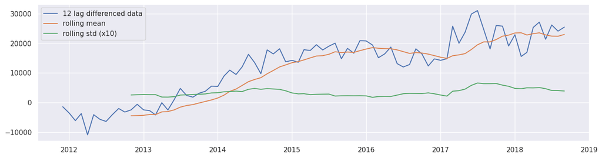

```
 > Is the 12 lag differenced data stationary ?
Test statistic = -1.180
P-value = 0.682
Critical values :
	1%: -3.5159766913976376 - The data is not stationary with 99% confidence
	5%: -2.898885703483903 - The data is not stationary with 95% confidence
	10%: -2.5866935058484217 - The data is not stationary with 90% confidence
```

```python
y_12lag =  y - y.shift(12)

test_stationarity(y_12lag,'12 lag differenced data')
ADF_test(y_12lag,'12 lag differenced data')
```

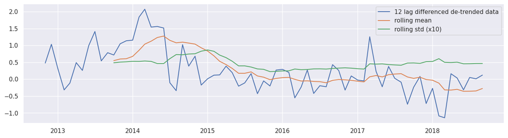

```
 > Is the 12 lag differenced de-trended data stationary ?
Test statistic = -2.131
P-value = 0.232
Critical values :
	1%: -3.530398990560757 - The data is not stationary with 99% confidence
	5%: -2.9050874099328317 - The data is not stationary with 95% confidence
	10%: -2.5900010121107266 - The data is not stationary with 90% confidence
```

```python
y_12lag_detrend =  y_detrend - y_detrend.shift(12)

test_stationarity(y_12lag_detrend,'12 lag differenced de-trended data')

ADF_test(y_12lag_detrend,'12 lag differenced de-trended data')
```

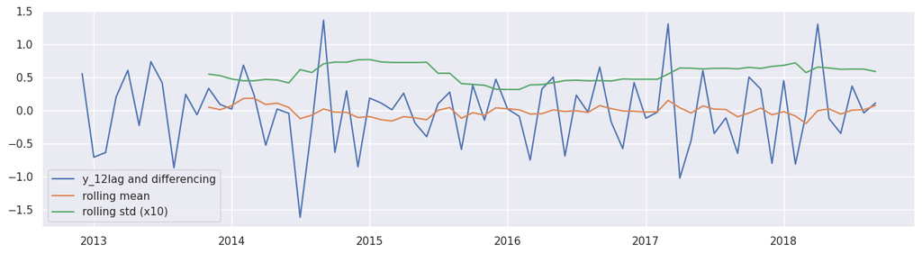

```
 > Is the y_12lag and differencing stationary ?
Test statistic = -9.450
P-value = 0.000
Critical values :
	1%: -3.530398990560757 - The data is  stationary with 99% confidence
	5%: -2.9050874099328317 - The data is  stationary with 95% confidence
	10%: -2.5900010121107266 - The data is  stationary with 90% confidence
```

```python
y_12lag_detrend =  y_detrend - y_detrend.shift(12)
y_12lag_diff = y_12lag_detrend.diff()

test_stationarity(y_12lag_diff, 'y_12lag and differencing')
ADF_test(y_12lag_diff, 'y_12lag and differencing')
```

```python
y_12lag_diff.to_csv("y_12lag_diff.csv") #saves the data to be used in the next stage as a CSV.
```

```python
!ls
```

```
LSOA_pop.csv			deprivation.gz	       violent_crimes.txt
all_crimes21_assignment.txt.gz	drug_incidents.txt     y_12lag_diff.csv
assignment.ipynb		firearm_incidents.txt
```

Claim 2

When completing data visualisations for claim 2, I will be using a bar chart. This will allow for the clearest representation of the data and will be ordered from highest to lowest on a basis of firearm incidents per 5000 people to allow for a fair representation from different areas. I will be using black for the bars. As Kashyap (2020) explains, 'use of color in a visualisation should be to help disseminate key findings instead of being part of some sort of artistic endeavor'. Murray (2019) takes this further in saying that data can be turned from an 'unassuming visualization into an emotion-filled data story' which can lead to inaccurate results and conclusions being taken. After completing this visualisation, I will then plot a scatterplot to explore whether there is a relationship between other features such as average income rank, employment rank or IMD rank can play an impact on firearm incidents too.

```python
%%time

top50pdf = complete_claim2_top50.toPandas() #converts the top 50 locations to a pandas dataframe
```

```
CPU times: user 16.9 ms, sys: 11.5 ms, total: 28.5 ms
Wall time: 2.09 s
```

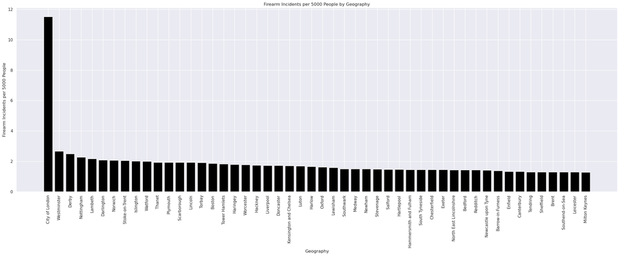

```
CPU times: user 1.2 s, sys: 160 ms, total: 1.36 s
Wall time: 1.24 s
```

```python
%%time

plt.figure(figsize=(24, 10))
plt.bar(top50pdf['Geography'], top50pdf['firearm_incidents_per_5000_people'], color='black')
plt.xlabel('Geography')
plt.ylabel('Firearm Incidents per 5000 People')
plt.title('Firearm Incidents per 5000 People by Geography')
plt.xticks(rotation=90)
plt.tight_layout()

# Display the chart
plt.show()
```

As seen from the above, Birmingham does not have the highest number of firearm incidents per head by location in the UK. The City of London has the highest number, followed by Westminster and Derby. This also does not take into account other areas of London such as Hackney which is placed in the top 50 results. Also as seen from above Birmingham does not appear within the list of locations.

After seeing this result, I wanted to explore the population dataset a little further and see if there was a relationship between the different location's income rank, employment rank or IMD rank.

```python
asc_population_df = (population_df
         .select("Geography", "Total")
         .orderBy(col("Total").asc()))
```

```python
%%time

asc_population_df.show()
```

```
+------------------+-----+
|         Geography|Total|
+------------------+-----+
|   Isles of Scilly| 2203|
|    City of London| 7375|
|     West Somerset|34675|
|           Rutland|37369|
|           Purbeck|44973|
|      Christchurch|47752|
|            Melton|50376|
|           Ryedale|51751|
|     Richmondshire|51965|
|              Eden|52564|
|        West Devon|53553|
|            Craven|55409|
| Oadby and Wigston|56170|
|     Ribble Valley|57132|
|    Merthyr Tydfil|58802|
|      Forest Heath|59748|
|              Adur|61182|
|             Corby|61255|
|            Maldon|61629|
|North Warwickshire|62014|
+------------------+-----+
only showing top 20 rows

CPU times: user 10.5 ms, sys: 1.58 ms, total: 12.1 ms
Wall time: 977 ms
```

As seen from above, the City of London has the second smallest population by the location names given. Despite this, the figures show that per head this location has the greatest firearm incidents per head. I now want to explore whether models can be made which use the firearm incidents per 5000 people to effectively pinpoint what the average income rank or average employment rank would be of a location. I will be doing the below through a linear regression model and plotting the prediction and actual results as a side by side bar chart.

```python
complete_claim2.show(3)
```

```
+--------------+---------------------------------+--------------+----------+-------------+-----------------+
|     Geography|firearm_incidents_per_5000_people|      LSOAName|AvgIMDRank|AvgIncomeRank|AvgEmploymentRank|
+--------------+---------------------------------+--------------+----------+-------------+-----------------+
|City of London|                          11.5254|City of London|   22758.0|      25764.0|          27831.0|
|   Westminster|                           2.6664|   Westminster|   13103.0|      16497.0|          19385.0|
|         Derby|                           2.4924|         Derby|   14924.0|      14554.0|          13693.0|
+--------------+---------------------------------+--------------+----------+-------------+-----------------+
only showing top 3 rows
```

```python
%%time

(trainDF, testDF) = complete_claim2.randomSplit([.8,.2],seed = 41)
```

```
CPU times: user 2.3 ms, sys: 349 µs, total: 2.65 ms
Wall time: 16.3 ms
```

```python
%%time

trainDF.count()
```

```
CPU times: user 13.7 ms, sys: 798 µs, total: 14.5 ms
Wall time: 2.42 s
```

```
244
```

```python
%%time

testDF.count()
```

```
CPU times: user 9.57 ms, sys: 4.25 ms, total: 13.8 ms
Wall time: 2.34 s
```

```
59
```

```python
%%time

vecAssembler = VectorAssembler(inputCols = ['firearm_incidents_per_5000_people'], outputCol = "features")
vecTrainDF = vecAssembler.transform(trainDF)

vecTrainDF.select('Geography', 'firearm_incidents_per_5000_people', 'features', 'AvgIncomeRank').show(4)
```

```
+--------------+---------------------------------+--------+-------------+
|     Geography|firearm_incidents_per_5000_people|features|AvgIncomeRank|
+--------------+---------------------------------+--------+-------------+
|     Charnwood|                            0.301| [0.301]|      20961.0|
|North Kesteven|                           0.1856|[0.1856]|      21053.0|
| Epping Forest|                            0.361| [0.361]|      19010.0|
|       Waveney|                           0.5206|[0.5206]|      13938.0|
+--------------+---------------------------------+--------+-------------+
only showing top 4 rows

CPU times: user 7.04 ms, sys: 254 µs, total: 7.29 ms
Wall time: 1.65 s
```

```python
lr = LinearRegression(featuresCol = "features", labelCol = "AvgIncomeRank")
lrModel = lr.fit(vecTrainDF)

pipeline = Pipeline(stages = [vecAssembler, lr])

pipelineModel = pipeline.fit(trainDF)
```

```python
m = round(lrModel.coefficients[0], 6)
b = round(lrModel.intercept, 2)

print(f"""The formula for the linear regression line is AvgIncomeRank = {m} * firearm_incidents_per_5000_people + {b}""")
```

```
The formula for the linear regression line is AvgIncomeRank = -1828.562003 * firearm_incidents_per_5000_people + 18884.94
```

```python
preDF = pipelineModel.transform(testDF)
```

```python
%%time

preDF.show()
```

```
+--------------------+---------------------------------+--------------------+----------+-------------+-----------------+--------+------------------+
|           Geography|firearm_incidents_per_5000_people|            LSOAName|AvgIMDRank|AvgIncomeRank|AvgEmploymentRank|features|        prediction|
+--------------------+---------------------------------+--------------------+----------+-------------+-----------------+--------+------------------+
|           Worcester|                           1.7718|           Worcester|   17127.0|      17401.0|          17334.0|[1.7718]|15645.097241728123|
|                Arun|                           0.4682|                Arun|   17074.0|      17644.0|          17363.0|[0.4682]|   18028.810668792|
|      Aylesbury Vale|                           0.7465|      Aylesbury Vale|   24273.0|      23673.0|          25599.0|[0.7465]| 17519.92186336712|
|          Sunderland|                           1.2159|          Sunderland|   10908.0|      11266.0|           7529.0|[1.2159]|16661.594859175813|
|            Bradford|                           1.0527|            Bradford|   11105.0|      12138.0|          12764.0|[1.0527]| 16960.01617805954|
|           Bassetlaw|                           1.0632|           Bassetlaw|   13182.0|      15860.0|          11897.0|[1.0632]|16940.816277028418|
|            Tamworth|                           0.9113|            Tamworth|   16357.0|      16317.0|          15991.0|[0.9113]| 17218.57484527865|
|          Eastbourne|                           0.8047|          Eastbourne|   12776.0|      14027.0|          12313.0|[0.8047]|17413.499554794613|
|              Oxford|                           1.6128|              Oxford|   15041.0|      18253.0|          21727.0|[1.6128]|  15935.8386001994|
|             Swindon|                           0.3347|             Swindon|   19391.0|      18463.0|          18681.0|[0.3347]|18272.923696187696|
|          Cheltenham|                           0.3456|          Cheltenham|   20611.0|      19922.0|          19685.0|[0.3456]|18252.992370355387|
|Blackburn with Da...|                            0.678|Blackburn with Da...|    9789.0|      10669.0|           8965.0| [0.678]|17645.178360570153|
|      South Somerset|                           0.3101|      South Somerset|   19947.0|      19611.0|          20104.0|[0.3101]| 18317.90632146061|
|              Dudley|                           0.3675|              Dudley|   15101.0|      14272.0|          13348.0|[0.3675]|18212.946862490477|
|             Norwich|                           2.0753|             Norwich|   12721.0|      12755.0|          13114.0|[2.0753]|15090.128673828549|
|           Doncaster|                           1.7196|           Doncaster|   11028.0|      13000.0|           9762.0|[1.7196]|15740.548178282845|
|  North Lincolnshire|                            0.866|  North Lincolnshire|   15566.0|      15782.0|          14413.0| [0.866]| 17301.40870401292|
|            Sandwell|                           0.5031|            Sandwell|    7068.0|       7805.0|           7788.0|[0.5031]| 17964.99385488856|
|              Newham|                           1.4936|              Newham|    4303.0|       3223.0|           8549.0|[1.4936]|16153.803190952709|
|           Sevenoaks|                           0.6093|           Sevenoaks|   24011.0|      22419.0|          25028.0|[0.6093]| 17770.80057017378|
+--------------------+---------------------------------+--------------------+----------+-------------+-----------------+--------+------------------+
only showing top 20 rows

CPU times: user 7.3 ms, sys: 500 µs, total: 7.8 ms
Wall time: 1.55 s
```

```python
preDF.createOrReplaceTempView("LinearView")
```

```python
%%time

lr_result = spark.sql("""SELECT
Geography, firearm_incidents_per_5000_people, l.AvgIncomeRank as IncomeRank,
prediction FROM LinearView l""")
```

```
CPU times: user 987 µs, sys: 0 ns, total: 987 µs
Wall time: 6.9 ms
```

```python
%%time

lr_result.show()
```

```
+--------------------+---------------------------------+----------+------------------+
|           Geography|firearm_incidents_per_5000_people|IncomeRank|        prediction|
+--------------------+---------------------------------+----------+------------------+
|           Worcester|                           1.7718|   17401.0|15645.097241728123|
|                Arun|                           0.4682|   17644.0|   18028.810668792|
|      Aylesbury Vale|                           0.7465|   23673.0| 17519.92186336712|
|          Sunderland|                           1.2159|   11266.0|16661.594859175813|
|            Bradford|                           1.0527|   12138.0| 16960.01617805954|
|           Bassetlaw|                           1.0632|   15860.0|16940.816277028418|
|            Tamworth|                           0.9113|   16317.0| 17218.57484527865|
|          Eastbourne|                           0.8047|   14027.0|17413.499554794613|
|              Oxford|                           1.6128|   18253.0|  15935.8386001994|
|             Swindon|                           0.3347|   18463.0|18272.923696187696|
|          Cheltenham|                           0.3456|   19922.0|18252.992370355387|
|Blackburn with Da...|                            0.678|   10669.0|17645.178360570153|
|      South Somerset|                           0.3101|   19611.0| 18317.90632146061|
|              Dudley|                           0.3675|   14272.0|18212.946862490477|
|             Norwich|                           2.0753|   12755.0|15090.128673828549|
|           Doncaster|                           1.7196|   13000.0|15740.548178282845|
|  North Lincolnshire|                            0.866|   15782.0| 17301.40870401292|
|            Sandwell|                           0.5031|    7805.0| 17964.99385488856|
|              Newham|                           1.4936|    3223.0|16153.803190952709|
|           Sevenoaks|                           0.6093|   22419.0| 17770.80057017378|
+--------------------+---------------------------------+----------+------------------+
only showing top 20 rows

CPU times: user 7.83 ms, sys: 487 µs, total: 8.32 ms
Wall time: 1.57 s
```

```python
%%time

p_lr = lr_result.toPandas()
```

```
CPU times: user 21.3 ms, sys: 788 µs, total: 22.1 ms
Wall time: 2.21 s
```

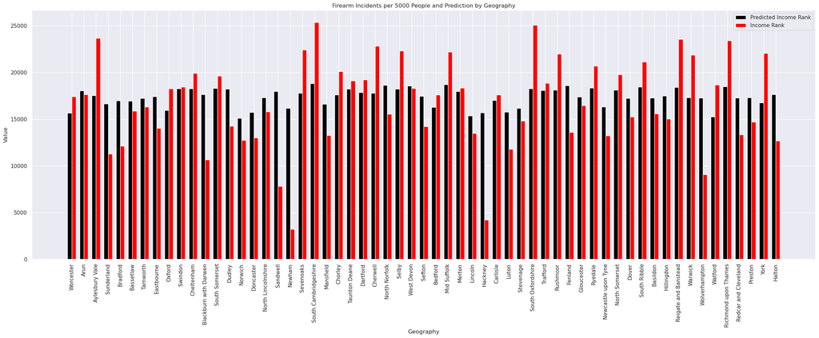

```python
x = np.arange(len(p_lr['Geography']))

# Set the width of each bar
bar_width = 0.35

plt.figure(figsize=(24, 10))

# Plot 'firearm_incidents_per_10000_people'
plt.bar(x - bar_width/2, p_lr['prediction'], bar_width, color='black', label='Predicted Income Rank')

# Plot 'prediction'
plt.bar(x + bar_width/2, p_lr['IncomeRank'], bar_width, color='red', label='Income Rank')

plt.xlabel('Geography')
plt.ylabel('Value')
plt.title('Firearm Incidents per 5000 People and Prediction by Geography')
plt.xticks(x, p_lr['Geography'], rotation=90)
plt.legend()

# Display the chart
plt.tight_layout()
plt.show()
```

```python
vecAssembler = VectorAssembler(inputCols = ['firearm_incidents_per_5000_people'], outputCol = "features")
vecTrainDF = vecAssembler.transform(trainDF)

vecTrainDF.select('Geography', 'firearm_incidents_per_5000_people', 'features', 'AvgEmploymentRank').show(4)
```

```
+--------------+---------------------------------+--------+-----------------+
|     Geography|firearm_incidents_per_5000_people|features|AvgEmploymentRank|
+--------------+---------------------------------+--------+-----------------+
|     Charnwood|                            0.301| [0.301]|          21796.0|
|North Kesteven|                           0.1856|[0.1856]|          20663.0|
| Epping Forest|                            0.361| [0.361]|          21181.0|
|       Waveney|                           0.5206|[0.5206]|          12983.0|
+--------------+---------------------------------+--------+-----------------+
only showing top 4 rows
```

```python
lr = LinearRegression(featuresCol = "features", labelCol = "AvgEmploymentRank")
lrModel = lr.fit(vecTrainDF)

pipeline = Pipeline(stages = [vecAssembler, lr])

pipelineModel = pipeline.fit(trainDF)
```

```python
m = round(lrModel.coefficients[0], 6)
b = round(lrModel.intercept, 2)

print(f"""The formula for the linear regression line is AvgEmploymentRank = {m} * firearm_incidents_per_5000_people + {b}""")
```

```
The formula for the linear regression line is AvgEmploymentRank = -1852.644311 * firearm_incidents_per_5000_people + 18904.98
```

```python
preDF = pipelineModel.transform(testDF)
```

```python
preDF.show()
```

```
+--------------------+---------------------------------+--------------------+----------+-------------+-----------------+--------+------------------+
|           Geography|firearm_incidents_per_5000_people|            LSOAName|AvgIMDRank|AvgIncomeRank|AvgEmploymentRank|features|        prediction|
+--------------------+---------------------------------+--------------------+----------+-------------+-----------------+--------+------------------+
|           Worcester|                           1.7718|           Worcester|   17127.0|      17401.0|          17334.0|[1.7718]|15622.466878849951|
|                Arun|                           0.4682|                Arun|   17074.0|      17644.0|          17363.0|[0.4682]|18037.574002901514|
|      Aylesbury Vale|                           0.7465|      Aylesbury Vale|   24273.0|      23673.0|          25599.0|[0.7465]|17521.983091100694|
|          Sunderland|                           1.2159|          Sunderland|   10908.0|      11266.0|           7529.0|[1.2159]| 16652.35185143377|
|            Bradford|                           1.0527|            Bradford|   11105.0|      12138.0|          12764.0|[1.0527]|16954.703403018008|
|           Bassetlaw|                           1.0632|           Bassetlaw|   13182.0|      15860.0|          11897.0|[1.0632]| 16935.25063775064|
|            Tamworth|                           0.9113|            Tamworth|   16357.0|      16317.0|          15991.0|[0.9113]| 17216.66730861857|
|          Eastbourne|                           0.8047|          Eastbourne|   12776.0|      14027.0|          12313.0|[0.8047]|17414.159192190138|
|              Oxford|                           1.6128|              Oxford|   15041.0|      18253.0|          21727.0|[1.6128]|15917.037324327244|
|             Swindon|                           0.3347|             Swindon|   19391.0|      18463.0|          18681.0|[0.3347]|18284.902018443772|
|          Cheltenham|                           0.3456|          Cheltenham|   20611.0|      19922.0|          19685.0|[0.3456]| 18264.70819545193|
|Blackburn with Da...|                            0.678|Blackburn with Da...|    9789.0|      10669.0|           8965.0| [0.678]|17648.889226416384|
|      South Somerset|                           0.3101|      South Somerset|   19947.0|      19611.0|          20104.0|[0.3101]| 18330.47706849875|
|              Dudley|                           0.3675|              Dudley|   15101.0|      14272.0|          13348.0|[0.3675]|18224.135285037133|
|             Norwich|                           2.0753|             Norwich|   12721.0|      12755.0|          13114.0|[2.0753]|15060.189330407447|
|           Doncaster|                           1.7196|           Doncaster|   11028.0|      13000.0|           9762.0|[1.7196]| 15719.17491189344|
|  North Lincolnshire|                            0.866|  North Lincolnshire|   15566.0|      15782.0|          14413.0| [0.866]| 17300.59209591493|
|            Sandwell|                           0.5031|            Sandwell|    7068.0|       7805.0|           7788.0|[0.5031]|17972.916716441407|
|              Newham|                           1.4936|              Newham|    4303.0|       3223.0|           8549.0|[1.4936]|16137.872526219655|
|           Sevenoaks|                           0.6093|           Sevenoaks|   24011.0|      22419.0|          25028.0|[0.6093]|17776.165890594308|
+--------------------+---------------------------------+--------------------+----------+-------------+-----------------+--------+------------------+
only showing top 20 rows
```

```python
preDF.createOrReplaceTempView("LinearView2")
```

```python
lr_result2 = spark.sql("""SELECT
Geography, firearm_incidents_per_5000_people, l.AvgEmploymentRank as EmploymentRank,
prediction FROM LinearView2 l""")
```

```python
lr_result2.show()
```

```
+--------------------+---------------------------------+--------------+------------------+
|           Geography|firearm_incidents_per_5000_people|EmploymentRank|        prediction|
+--------------------+---------------------------------+--------------+------------------+
|           Worcester|                           1.7718|       17334.0|15622.466878849951|
|                Arun|                           0.4682|       17363.0|18037.574002901514|
|      Aylesbury Vale|                           0.7465|       25599.0|17521.983091100694|
|          Sunderland|                           1.2159|        7529.0| 16652.35185143377|
|            Bradford|                           1.0527|       12764.0|16954.703403018008|
|           Bassetlaw|                           1.0632|       11897.0| 16935.25063775064|
|            Tamworth|                           0.9113|       15991.0| 17216.66730861857|
|          Eastbourne|                           0.8047|       12313.0|17414.159192190138|
|              Oxford|                           1.6128|       21727.0|15917.037324327244|
|             Swindon|                           0.3347|       18681.0|18284.902018443772|
|          Cheltenham|                           0.3456|       19685.0| 18264.70819545193|
|Blackburn with Da...|                            0.678|        8965.0|17648.889226416384|
|      South Somerset|                           0.3101|       20104.0| 18330.47706849875|
|              Dudley|                           0.3675|       13348.0|18224.135285037133|
|             Norwich|                           2.0753|       13114.0|15060.189330407447|
|           Doncaster|                           1.7196|        9762.0| 15719.17491189344|
|  North Lincolnshire|                            0.866|       14413.0| 17300.59209591493|
|            Sandwell|                           0.5031|        7788.0|17972.916716441407|
|              Newham|                           1.4936|        8549.0|16137.872526219655|
|           Sevenoaks|                           0.6093|       25028.0|17776.165890594308|
+--------------------+---------------------------------+--------------+------------------+
only showing top 20 rows
```

```python
p_lr2 = lr_result2.toPandas()
```

[figure not shown]

```python
x = np.arange(len(p_lr2['Geography']))

# Set the width of each bar
bar_width = 0.35

plt.figure(figsize=(24, 10))

# Plot 'firearm_incidents_per_10000_people'
plt.bar(x - bar_width/2, p_lr2['prediction'], bar_width, color='black', label='Predicted Income Rank')

# Plot 'prediction'
plt.bar(x + bar_width/2, p_lr2['EmploymentRank'], bar_width, color='red', label='Income Rank')

plt.xlabel('Geography')
plt.ylabel('Value')
plt.title('Firearm Incidents per 5000 People and Prediction by Geography')
plt.xticks(x, p_lr['Geography'], rotation=90)
plt.legend()

# Display the chart
plt.tight_layout()
plt.show()
```

Claim 3

Finally, for claim 3, I will use a scatterplot to model the relationship between the drug offences and the firearm incidents which will have already been filtered from above. I will be using Pearson’s Correlation matrix to identify the strength of the relationship between these two variables accounting a numerical value. As Ngueynm Adams and Miller (2023) state, 'Pearson is a test that measures the linear correlation between two variables' and would be the most appropriate for measuring the relationship between drugs offences and firearm incidents.

```python
x = combined.select("drug_count").rdd.flatMap(lambda x: x).collect()
y = combined.select("firearm_count").rdd.flatMap(lambda x: x).collect()
```

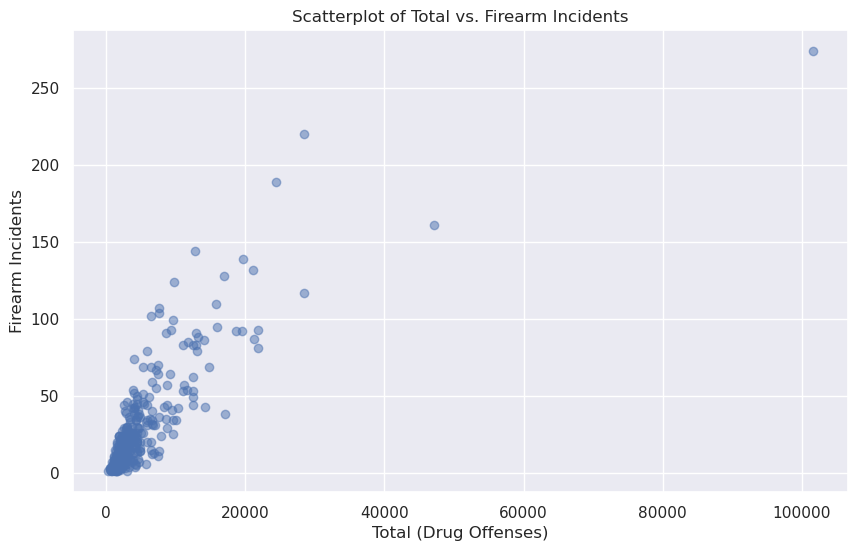

```python
plt.figure(figsize=(10, 6))  # Adjust the figure size as needed
plt.scatter(x, y, alpha=0.5)  # Create the scatterplot
plt.title("Scatterplot of Total vs. Firearm Incidents")  # Set the plot title
plt.xlabel("Total (Drug Offenses)")  # Set the x-axis label
plt.ylabel("Firearm Incidents")  # Set the y-axis label
plt.grid(True)  # Add a grid for better readability
plt.show()  # Display the plot
```

As seen from the above scatterplot, the 'no location given' affects the plot significantly. As a result, I will create a new plot which removes this figure.

```python
combined.createOrReplaceTempView("combined_offences")
```

```python
#removes no location

nl_removed_df = spark.sql("""SELECT * FROM combined_offences
WHERE LSOAName <> 'No Location Given'
ORDER BY combined_offences.drug_count DESC""")
```

```python
nl_removed_df.show()
```

```
+-------------------+----------+-------------+
|           LSOAName|drug_count|firearm_count|
+-------------------+----------+-------------+
|          Liverpool|     47201|          161|
|        Westminster|     28499|          117|
|         Birmingham|     28425|          220|
|              Leeds|     24494|          189|
|      Tower Hamlets|     21886|           93|
|              Brent|     21841|           81|
|          Southwark|     21232|           87|
|            Lambeth|     21136|          132|
|         Nottingham|     19743|          139|
|             Newham|     19522|           92|
|            Croydon|     18643|           92|
|             Camden|     17065|           38|
|         Manchester|     17017|          128|
|            Cardiff|     15992|           95|
|           Bradford|     15867|          110|
|             Ealing|     14778|           69|
|             Sefton|     14208|           43|
|            Hackney|     14125|           86|
|           Lewisham|     13217|           88|
|Newcastle upon Tyne|     13121|           79|
+-------------------+----------+-------------+
only showing top 20 rows
```

```python
x = nl_removed_df.select("drug_count").rdd.flatMap(lambda x: x).collect()
y = nl_removed_df.select("firearm_count").rdd.flatMap(lambda x: x).collect()
```

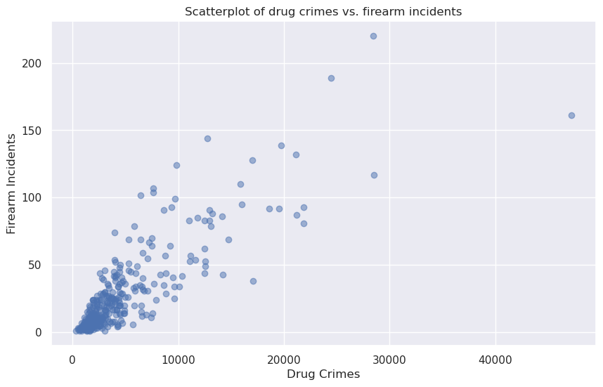

```python
plt.figure(figsize=(10, 6))  # Adjust the figure size as needed
plt.scatter(x, y, alpha=0.5)  # Create the scatterplot
plt.title("Scatterplot of drug crimes vs. firearm incidents")  # Set the plot title
plt.xlabel("Drug Crimes")  # Set the x-axis label
plt.ylabel("Firearm Incidents")  # Set the y-axis label
plt.grid(True)  # Add a grid for better readability
plt.show()  # Display the plot
```

```python
selected_data = nl_removed_df.select("drug_count", "firearm_count")

# Convert the DataFrame to a format suitable for correlation analysis
data = [Row(features=Vectors.dense(row)) for row in selected_data.collect()]

# Create a new DataFrame with the suitable format
df = spark.createDataFrame(data, ["features"])

# Calculate the Pearson correlation matrix - USE PEARSON AS IT IS A LINEAR RELATIONSHIP
r1 = Correlation.corr(df, "features").head()
print("Pearson correlation matrix:\n" + str(r1[0]))
```

```
Pearson correlation matrix:
DenseMatrix([[1.        , 0.83993104],
             [0.83993104, 1.        ]])
```

As seen from the above, the correlation between the two variables is very strong. With a score of 0.83, there is a clear positive relationship between drug offences and firearm offences. However, by looking at the above, it is clear that further classification can be achieved through clustering the data points together based on their location within the scatterplot. As the results are linear, I wanted to examine the linear regression which will be completed within the evaluative models.

# Part 5 - Selection, application, and reasoning behind use of statistical analysis and multiple evaluation measures

After applying the most appropriate model, I will use this to explore the forecast for the time points inputted below. I will then create tables to highlight the upper and lower bounds, as well as the mean between these two values. Finally, I will be using a range of evaluative values to explore how well the model fits with the data.

For claim 2, I will be using the RMSE evaluator for linear regression to understand the performance of both models I have created.

For claim 3, I will be using clustering. This will identify clusters of locations for where there are the most firearm and drug offences. I will finally use a clustering evaluator to understand the centers of each cluster.

```python
file = "y_12lag_diff.csv"
pdf = pd.read_csv(file,parse_dates = ['MonthYear'])
```

```python
pdf.MonthYear = pdf.MonthYear.astype('datetime64[ns]')
y = pdf.set_index(pd.to_datetime(pdf.MonthYear)).dropna().Total
y.head
```

```
<bound method NDFrame.head of MonthYear
2012-12-01    0.55480851
2013-01-01   -0.71059403
2013-02-01   -0.63975609
2013-03-01    0.20210082
2013-04-01    0.60556791
                 ...
2018-05-01   -0.12625104
2018-06-01   -0.34998136
2018-07-01    0.36616447
2018-08-01   -0.03968387
2018-09-01    0.10980110
Name: Total, Length: 70, dtype: float64>
```

```python
y_to_train = y[:'2015-10-01']
y_to_test = y['2015-11-01':]
#predict_date = len(y) - len(y[:'2019-02-01']) # the number of data points for the test set
y_to_val = y_to_test

print(len(y_to_train))
print(len(y_to_test))
```

```
35
35
```

```python
warnings.filterwarnings("ignore") # specify to ignore warning messages

p = d = q = range(0, 2)
seasonal_period = 12
pdq = list(itertools.product(p, d, q))
seasonal_pdq = [(x[0], x[1], x[2],seasonal_period) for x in list(itertools.product(p, d, q))]

print('Examples of parameter combinations for Seasonal ARIMA...')
print('SARIMAX: {} x {}'.format(pdq[1], seasonal_pdq[1]))
print('SARIMAX: {} x {}'.format(pdq[1], seasonal_pdq[2]))
print('SARIMAX: {} x {}'.format(pdq[2], seasonal_pdq[3]))
print('SARIMAX: {} x {}'.format(pdq[2], seasonal_pdq[4]))
```

```
Examples of parameter combinations for Seasonal ARIMA...
SARIMAX: (0, 0, 1) x (0, 0, 1, 12)
SARIMAX: (0, 0, 1) x (0, 1, 0, 12)
SARIMAX: (0, 1, 0) x (0, 1, 1, 12)
SARIMAX: (0, 1, 0) x (1, 0, 0, 12)
```

```python
for param in pdq:
    for param_seasonal in seasonal_pdq:
        try:
            mod =\
            sm.tsa.statespace.SARIMAX(y_to_train,
                                      order=param,
                                      seasonal_order=param_seasonal,
                                      enforce_invertibility=False)
            results = mod.fit()
            print('ARIMA{}x{}12 - AIC:{}'.format(param, param_seasonal, results.aic))
        except Exception as ex:
            print(ex)
            continue
```

```
ARIMA(0, 0, 0)x(0, 0, 0, 12)12 - AIC:60.1168025331584
ARIMA(0, 0, 0)x(0, 0, 1, 12)12 - AIC:59.90836823917669
ARIMA(0, 0, 0)x(0, 1, 0, 12)12 - AIC:64.88003466729124
ARIMA(0, 0, 0)x(0, 1, 1, 12)12 - AIC:61.17068563896878
ARIMA(0, 0, 0)x(1, 0, 0, 12)12 - AIC:60.55447957602839
ARIMA(0, 0, 0)x(1, 0, 1, 12)12 - AIC:60.807617751741184
ARIMA(0, 0, 0)x(1, 1, 0, 12)12 - AIC:60.652506734419575
ARIMA(0, 0, 0)x(1, 1, 1, 12)12 - AIC:62.6525053046267
ARIMA(0, 0, 1)x(0, 0, 0, 12)12 - AIC:59.269482059268
ARIMA(0, 0, 1)x(0, 0, 1, 12)12 - AIC:58.58205356145638
ARIMA(0, 0, 1)x(0, 1, 0, 12)12 - AIC:65.91252676493619
ARIMA(0, 0, 1)x(0, 1, 1, 12)12 - AIC:61.572084018260284
ARIMA(0, 0, 1)x(1, 0, 0, 12)12 - AIC:59.20765042621219
ARIMA(0, 0, 1)x(1, 0, 1, 12)12 - AIC:59.69443110168543
ARIMA(0, 0, 1)x(1, 1, 0, 12)12 - AIC:60.522920446840864
ARIMA(0, 0, 1)x(1, 1, 1, 12)12 - AIC:62.52291863149856
ARIMA(0, 1, 0)x(0, 0, 0, 12)12 - AIC:88.64194831150503
ARIMA(0, 1, 0)x(0, 0, 1, 12)12 - AIC:89.41658808143576
ARIMA(0, 1, 0)x(0, 1, 0, 12)12 - AIC:80.2999557518052
ARIMA(0, 1, 0)x(0, 1, 1, 12)12 - AIC:77.41112456276397
ARIMA(0, 1, 0)x(1, 0, 0, 12)12 - AIC:89.79054617486334
ARIMA(0, 1, 0)x(1, 0, 1, 12)12 - AIC:90.3333546341808
ARIMA(0, 1, 0)x(1, 1, 0, 12)12 - AIC:77.13204394453788
ARIMA(0, 1, 0)x(1, 1, 1, 12)12 - AIC:79.13204049906274
ARIMA(0, 1, 1)x(0, 0, 0, 12)12 - AIC:64.97196444771008
ARIMA(0, 1, 1)x(0, 0, 1, 12)12 - AIC:65.21423335366312
ARIMA(0, 1, 1)x(0, 1, 0, 12)12 - AIC:68.21259185872293
ARIMA(0, 1, 1)x(0, 1, 1, 12)12 - AIC:65.22862130325957
ARIMA(0, 1, 1)x(1, 0, 0, 12)12 - AIC:65.7056899309602
ARIMA(0, 1, 1)x(1, 0, 1, 12)12 - AIC:66.20189366378807
ARIMA(0, 1, 1)x(1, 1, 0, 12)12 - AIC:64.89848499193567
ARIMA(0, 1, 1)x(1, 1, 1, 12)12 - AIC:66.89848087508392
ARIMA(1, 0, 0)x(0, 0, 0, 12)12 - AIC:60.6518369576316
ARIMA(1, 0, 0)x(0, 0, 1, 12)12 - AIC:60.020591970812006
ARIMA(1, 0, 0)x(0, 1, 0, 12)12 - AIC:66.5319111549946
ARIMA(1, 0, 0)x(0, 1, 1, 12)12 - AIC:62.48591641703874
ARIMA(1, 0, 0)x(1, 0, 0, 12)12 - AIC:60.698987573077986
ARIMA(1, 0, 0)x(1, 0, 1, 12)12 - AIC:61.051585926131565
ARIMA(1, 0, 0)x(1, 1, 0, 12)12 - AIC:61.7522225361144
ARIMA(1, 0, 0)x(1, 1, 1, 12)12 - AIC:63.70211242347872
```

[output cut: 9 more lines]

```
ARIMA(1, 1, 0)x(0, 0, 1, 12)12 - AIC:81.46206357345376
ARIMA(1, 1, 0)x(0, 1, 0, 12)12 - AIC:79.43571262376226
ARIMA(1, 1, 0)x(0, 1, 1, 12)12 - AIC:75.76554116219589
ARIMA(1, 1, 0)x(1, 0, 0, 12)12 - AIC:82.23024289624617
ARIMA(1, 1, 0)x(1, 0, 1, 12)12 - AIC:82.44183127449199
ARIMA(1, 1, 0)x(1, 1, 0, 12)12 - AIC:75.39636546811485
ARIMA(1, 1, 0)x(1, 1, 1, 12)12 - AIC:77.1853940477253
ARIMA(1, 1, 1)x(0, 0, 0, 12)12 - AIC:65.85713769204742
ARIMA(1, 1, 1)x(0, 0, 1, 12)12 - AIC:65.70667426042067
ARIMA(1, 1, 1)x(0, 1, 0, 12)12 - AIC:70.05442312489866
ARIMA(1, 1, 1)x(0, 1, 1, 12)12 - AIC:66.82189261199437
ARIMA(1, 1, 1)x(1, 0, 0, 12)12 - AIC:66.24838032761105
ARIMA(1, 1, 1)x(1, 0, 1, 12)12 - AIC:66.79671080721656
ARIMA(1, 1, 1)x(1, 1, 0, 12)12 - AIC:66.35941471089443
ARIMA(1, 1, 1)x(1, 1, 1, 12)12 - AIC:68.32955114070748
```

```python
order = (1, 0, 0)
seasonal_order = (0, 0, 1, 12)
model = sm.tsa.statespace.SARIMAX(y_to_train,
                            order=order,
                            seasonal_order=seasonal_order,
                            enforce_invertibility=False)
results = model.fit()
```

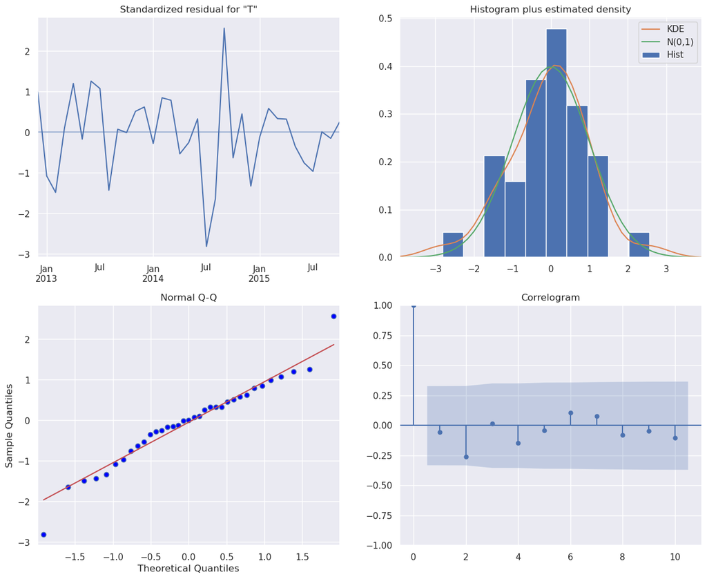

```python
results.plot_diagnostics(figsize=(15, 12))
plt.show()
```

```python
pred_uc = results.get_forecast(steps=12)

pred_ci = pred_uc.conf_int(alpha=0.1)
```

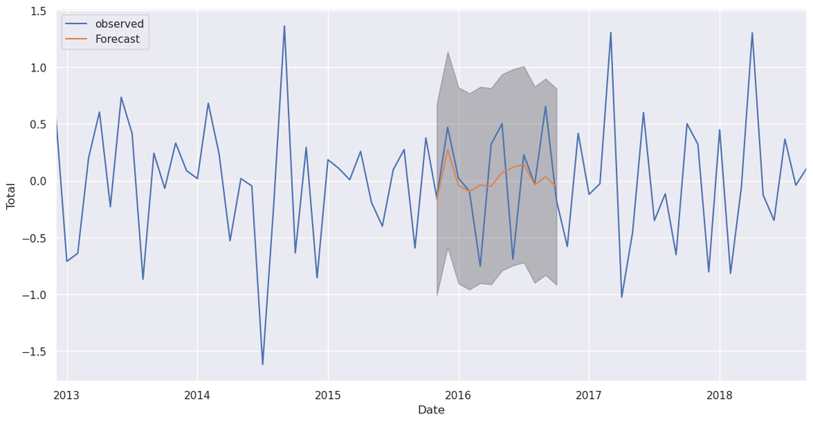

```python
ax = y.plot(label='observed', figsize=(14, 7))
#     print(pred_uc.predicted_mean)
pred_uc.predicted_mean.plot(ax=ax, label='Forecast')
ax.fill_between(pred_ci.index,
                pred_ci.iloc[:, 0],
                pred_ci.iloc[:, 1], color='k', alpha=.25)
ax.set_xlabel('Date')
ax.set_ylabel(y.name)

plt.legend()
plt.show()
```

```python
pm = pred_uc.predicted_mean.reset_index()
pm.columns = ['Date','Predicted_Mean']
pci = pred_ci.reset_index()
pci.columns = ['Date','Lower Bound','Upper Bound']
final_table = pm.join(pci.set_index('Date'), on='Date')
```

```python
final_table.head(12)
```

|  | Date | Predicted_Mean | Lower Bound | Upper Bound |
| --- | --- | --- | --- | --- |
| 0 | 2015-11-01 | -0.16718700 | -1.00945166 | 0.67507765 |
| 1 | 2015-12-01 | 0.27396508 | -0.58959344 | 1.13752361 |
| 2 | 2016-01-01 | -0.04206897 | -0.90675891 | 0.82262096 |
| 3 | 2016-02-01 | -0.09499869 | -0.95974806 | 0.76975068 |
| 4 | 2016-03-01 | -0.03819813 | -0.90295063 | 0.82655436 |
| 5 | 2016-04-01 | -0.04894447 | -0.91369713 | 0.81580819 |
| 6 | 2016-05-01 | 0.07277982 | -0.79197285 | 0.93753249 |
| 7 | 2016-06-01 | 0.11738644 | -0.74736623 | 0.98213911 |
| 8 | 2016-07-01 | 0.14443844 | -0.72031423 | 1.00919111 |
| 9 | 2016-08-01 | -0.03519126 | -0.89994393 | 0.82956141 |
| 10 | 2016-09-01 | 0.03459701 | -0.83015565 | 0.89934967 |
| 11 | 2016-10-01 | -0.05299457 | -0.91774704 | 0.81175791 |

```python
y_to_test.head(12)
```

```
MonthYear
2015-11-01   -0.14913853
2015-12-01    0.47058712
2016-01-01    0.02144018
2016-02-01   -0.09179904
2016-03-01   -0.75289047
2016-04-01    0.32131921
2016-05-01    0.50215042
2016-06-01   -0.69222555
2016-07-01    0.22847623
2016-08-01   -0.03092056
2016-09-01    0.65409530
2016-10-01   -0.17209078
Name: Total, dtype: float64
```

```python
def timeseries_evaluation_metrics_func(y_train, y_test):
    def mean_absolute_percentage_error(y_true, y_pred):
        y_true, y_pred = np.array(y_true), np.array(y_pred)
        return np.mean(np.abs((y_true - y_pred) / y_true)) * 100

    print('Evaluation metric results:')
    print(f'MSE is: {metrics.mean_squared_error(y_train, y_test)}')
    print(f'MAE is: {metrics.mean_absolute_error(y_train, y_test)}')
    print(f'RMSE is: {np.sqrt(metrics.mean_squared_error(y_train, y_test))}')
    print(f'MAPE is: {mean_absolute_percentage_error(y_train, y_test)}')
    print(f'R2 is: {metrics.r2_score(y_train, y_test)}')
```

```python
order = (1, 0, 1)
seasonal_order = (1, 0, 0, 12)
model = sm.tsa.statespace.SARIMAX(y_to_train,
                            order=order,
                            seasonal_order=seasonal_order,
                            enforce_invertibility=False)
results = model.fit()
```

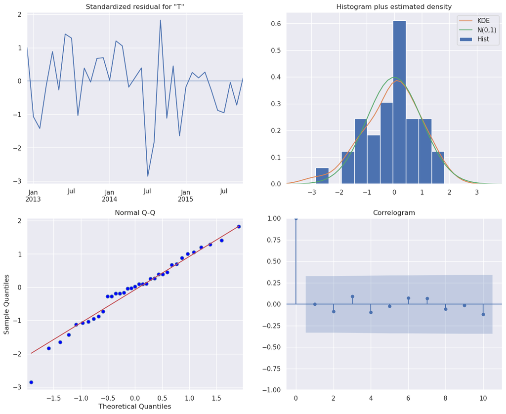

```python
results.plot_diagnostics(figsize=(15, 12))
plt.show()
```

```python
pred_uc = results.get_forecast(steps=12)

pred_ci = pred_uc.conf_int(alpha=0.1)
```

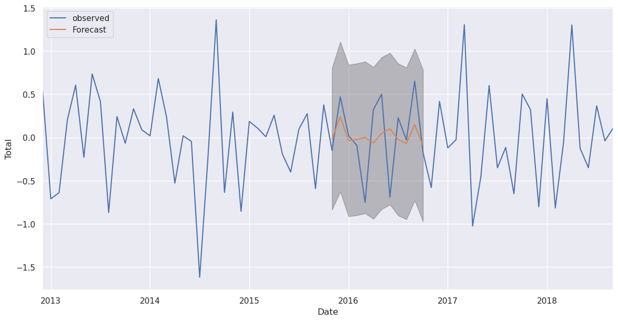

```python
ax = y.plot(label='observed', figsize=(14, 7))
#     print(pred_uc.predicted_mean)
pred_uc.predicted_mean.plot(ax=ax, label='Forecast')
ax.fill_between(pred_ci.index,
                pred_ci.iloc[:, 0],
                pred_ci.iloc[:, 1], color='k', alpha=.25)
ax.set_xlabel('Date')
ax.set_ylabel(y.name)

plt.legend()
plt.show()
```

```python
pm = pred_uc.predicted_mean.reset_index()
pm.columns = ['Date','Predicted_Mean']
pci = pred_ci.reset_index()
pci.columns = ['Date','Lower Bound','Upper Bound']
final_table = pm.join(pci.set_index('Date'), on='Date')
```

```python
final_table.head(12)
```

|  | Date | Predicted_Mean | Lower Bound | Upper Bound |
| --- | --- | --- | --- | --- |
| 0 | 2015-11-01 | -0.01613609 | -0.83641776 | 0.80414559 |
| 1 | 2015-12-01 | 0.23919498 | -0.62975790 | 1.10814787 |
| 2 | 2016-01-01 | -0.03591567 | -0.91348053 | 0.84164919 |
| 3 | 2016-02-01 | -0.02265148 | -0.90178271 | 0.85647975 |
| 4 | 2016-03-01 | -0.00011136 | -0.87952884 | 0.87930612 |
| 5 | 2016-04-01 | -0.06392832 | -0.94339816 | 0.81554152 |
| 6 | 2016-05-01 | 0.04838444 | -0.83109498 | 0.92786386 |
| 7 | 2016-06-01 | 0.10061762 | -0.77886355 | 0.98009879 |
| 8 | 2016-07-01 | -0.02408061 | -0.90356210 | 0.85540088 |
| 9 | 2016-08-01 | -0.06893330 | -0.94841485 | 0.81054825 |
| 10 | 2016-09-01 | 0.14881521 | -0.73066635 | 1.02829677 |
| 11 | 2016-10-01 | -0.09463567 | -0.97411723 | 0.78484589 |

```python
y_to_test.head(12)
```

```
MonthYear
2015-11-01   -0.14913853
2015-12-01    0.47058712
2016-01-01    0.02144018
2016-02-01   -0.09179904
2016-03-01   -0.75289047
2016-04-01    0.32131921
2016-05-01    0.50215042
2016-06-01   -0.69222555
2016-07-01    0.22847623
2016-08-01   -0.03092056
2016-09-01    0.65409530
2016-10-01   -0.17209078
Name: Total, dtype: float64
```

Claim 2

```python
regressionEvaluator = RegressionEvaluator(
 predictionCol="prediction",
 labelCol="AvgIncomeRank",
 metricName="rmse")
rmse = regressionEvaluator.evaluate(preDF)
print(f"RMSE is {rmse:.1f}")
```

```
RMSE is 4377.2
```

```python
def runlr(trainDF, testDF, feature_cols):
    vecAssembler = VectorAssembler(inputCols=feature_cols, outputCol="features")
    vecTrainDF = vecAssembler.transform(trainDF)
    lr = LinearRegression(featuresCol="features", labelCol="AvgIncomeRank")
    lrModel = lr.fit(vecTrainDF)
    pipeline = Pipeline(stages=[vecAssembler, lr])
    pipelineModel = pipeline.fit(trainDF)
    return pipelineModel.transform(testDF)
```

```python
predDF = runlr(trainDF, testDF, ['firearm_incidents_per_5000_people', 'AvgIMDRank', 'AvgEmploymentRank'])
```

```python
rmse = regressionEvaluator.evaluate(predDF)
print(f"RMSE is {rmse:.3f}")
```

```
RMSE is 1187.993
```

```python
pandf = predDF.select( "AvgIncomeRank", "prediction").toPandas()

ax =sns.regplot(x= 'AvgIncomeRank', y='prediction', data = pandf)
```

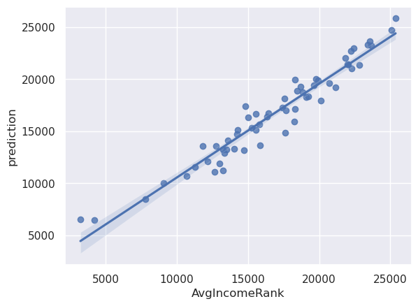

```python
plt.show()
```

```python
regressionEvaluator = RegressionEvaluator(
 predictionCol="prediction",
 labelCol="AvgEmploymentRank",
 metricName="rmse")
rmse = regressionEvaluator.evaluate(preDF)
print(f"RMSE is {rmse:.1f}")
```

```
RMSE is 5315.9
```

```python
def runlr(trainDF, testDF, feature_cols):
    vecAssembler = VectorAssembler(inputCols=feature_cols, outputCol="features")
    vecTrainDF = vecAssembler.transform(trainDF)
    lr = LinearRegression(featuresCol="features", labelCol="AvgEmploymentRank")
    lrModel = lr.fit(vecTrainDF)
    pipeline = Pipeline(stages=[vecAssembler, lr])
    pipelineModel = pipeline.fit(trainDF)
    return pipelineModel.transform(testDF)
```

```python
predDF = runlr(trainDF, testDF, ['firearm_incidents_per_5000_people', 'AvgIMDRank', 'AvgIncomeRank'])
```

```python
rmse = regressionEvaluator.evaluate(predDF)
print(f"RMSE is {rmse:.3f}")
```

```
RMSE is 1926.003
```

```python
pandf = predDF.select( "AvgEmploymentRank", "prediction").toPandas()

ax =sns.regplot(x= 'AvgEmploymentRank', y='prediction', data = pandf)
```

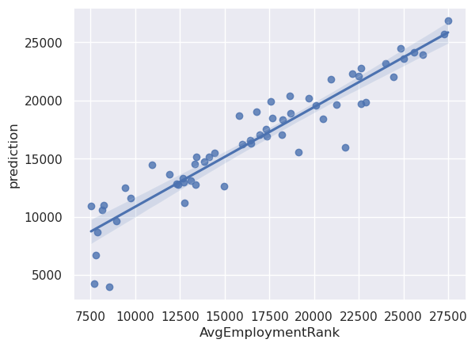

```python
plt.show()
```

Claim 3

```python
feature_cols = ['drug_count']  # Adjust based on your feature columns
assembler = VectorAssembler(inputCols=feature_cols, outputCol='features')
df = assembler.transform(nl_removed_df)

train_data, test_data = df.randomSplit([0.7, 0.3], seed=42)  # Adjust the split ratio as needed

lr = LinearRegression(featuresCol='features', labelCol='firearm_count')
lr_model = lr.fit(train_data)

predictions = lr_model.transform(test_data)

evaluator = RegressionEvaluator(labelCol='firearm_count', predictionCol='prediction', metricName='rmse')
rmse = evaluator.evaluate(predictions)
print("Root Mean Squared Error (RMSE):", rmse)
```

```
Root Mean Squared Error (RMSE): 21.207831592206308
```

```python
feature_cols = ['drug_count', 'firearm_count']

# Assemble the feature columns into a single vector column
assembler = VectorAssembler(inputCols=feature_cols, outputCol='features')
data = assembler.transform(nl_removed_df)

# Create a K-means clustering model
kmeans = KMeans(k=3, seed=1)  # You can adjust the number of clusters (k) as needed

# Fit the model to the data
model = kmeans.fit(data)

# Get cluster assignments for each row
clusters = model.transform(data)

# Show the cluster assignments
sorted_clusters = clusters.select('LSOAName', 'drug_count', 'firearm_count', 'prediction').orderBy('LSOAName')


sorted_clusters.show()
```

```
+--------------------+----------+-------------+----------+
|            LSOAName|drug_count|firearm_count|prediction|
+--------------------+----------+-------------+----------+
|                Adur|      1301|            2|         1|
|           Allerdale|      2517|           19|         1|
|        Amber Valley|      2322|           27|         1|
|                Arun|      3445|           14|         1|
|            Ashfield|      2722|           20|         1|
|             Ashford|      1855|           14|         1|
|      Aylesbury Vale|      3461|           26|         1|
|             Babergh|      1384|            3|         1|
|Barking and Dagenham|      9502|           41|         0|
|              Barnet|      8275|           43|         0|
|            Barnsley|      6665|           59|         0|
|   Barrow-in-Furness|      1883|           19|         1|
|            Basildon|      5916|           31|         1|
|Basingstoke and D...|      4462|           14|         1|
|           Bassetlaw|      1949|           24|         1|
|Bath and North Ea...|      2643|            5|         1|
|             Bedford|      3883|           45|         1|
|              Bexley|      6516|           15|         1|
|          Birmingham|     28425|          220|         2|
|Blackburn with Da...|      2949|           20|         1|
+--------------------+----------+-------------+----------+
only showing top 20 rows
```

```python
cluster_counts = clusters.groupBy('prediction').count()

cluster_counts.show()
```

```
+----------+-----+
|prediction|count|
+----------+-----+
|         1|  273|
|         2|   11|
|         0|   52|
+----------+-----+
```

```python
evaluator = ClusteringEvaluator()


silhouette = evaluator.evaluate(clusters)
print("Silhoutte with squared euclidean distance = " + str(silhouette))

centers = model.clusterCenters()
print("Cluster Centers: ")
for center in centers:
    print(center)
```

```
Silhoutte with squared euclidean distance = 0.8478109949200479
Cluster Centers:
[10422.88461538    62.65384615]
[2801.79120879   16.76556777]
[24783.81818182   127.54545455]
```

# Part 6 - Detailed Analysis and consideration of the appropriateness of the solution for the initial problem

For each claim, I will consider the advantages, disadvantages and limitations of the methods used.

For the first claim, a time series analysis was used to understand the trends that were happening year on year and evaluating whether this could be used to accurately forecast future changes in violent crimes. The main disadvantage of the time series was how it wouldn't become stationary without significant differencing. Whilst an ok method to use, completing too much differencing can result in some of the key trends disappearing from the final results. Furthermore, as explored in the analysis of the time series, the bounds either side of the predicted mean offer substantial margins meaning an accurate forecast has not really been made. While I used 2 of the ARIMA models, more time could have been given to exploring better fits which would have resulted in a more accurate forecast. Despite this, some of the trends have been accurately mapped so a shorter time scale may reflect an accurate forecast.

For the second claim, the use of bar charts, while simple in effect, provided a clear visual representation of the data and showed how Birmingham does not have the highest amount of firearm incidents per head in the UK (changed to per 5000 throughout in this report). As Birmingham was the focal point, on reflection, writing a query which includes the top 50 and Birmingham would have perhaps been better suited. I would have liked to have included a chorograph to display this data however could not execute this effectively. This was the claim I had more issues with proving through statistics and machine learning models hence why I went down the route of creating a prediction model based on the different ranks to see the effect it had on firearm incidents.

My final thought on the above is the use of grouping the data by the main location throughout(e.g. Birmingham instead of Birmingham 003A). I feel this made it easier to analyse the data by location especially for claims 2 and 3, however there may be certain relationships that weren't able to be analysed effectively due to this chosen route. The average income rank and employment rank for example had to be averaged to be able to be analysed in this way meaning lower ranked areas were combined with higher ranked areas. This is something that should also be considered throughout.

Overall, I feel that whilst I am able to justify the above claims, some of the above models, statistics and initial filtering could be changed to create improved analysis against the claims. Naturally, this will come with more practice and experience with similar datasets.

# Evaluation and Conclusion

Claim 1 - Violent Crime is increasing

On the one hand, I agree with this statement. As seen from the initial plot of the data, there are increases on a year by year basis. However, this does not tell the full picture. When exploring the seasonal analysis, it is clear that there are changes within a year particularly around the Summer months. As explained above and covered by the media, the Summer months and accompanied weather results in people being outside more and increased levels of alcohol levels. This results in greater levels of violent crimes during the Summer months. The seasonal changes are not always consistent however.

Claim 2 - There are more firearms incidents per head in Birmingham than anywhere else in the UK.

I disagree with this statement. After completing the filtering and dividing the number of firearms by a location's population, City of London has the highest number of firearm incidents. As examined above, it should also be noted that the City of London also has one of the smallest populations as per the LSOA population dataset. Even if this were taken out of the situation, there are other locations which rank higher than Birmingham for firearm incidents. It should be noted however that Birmingham does have the highest number of firearm incidents in the UK when per head characteristics are not taken into account.

Claim 3 - Crimes involving firearms are closely associated with drugs offences

# References

Sedkaoui, S. (2018). Data analytics and big data. London: John Wiley and Sons.

Nudurupari, S. (2021). Essential PySpark for Scalable Data Analytics. Available at: https://learning.oreilly.com/library/view/essential-pyspark-for/9781800568877/B16736_FM_Final_JM_ePub.xhtml

Hodeghatta, U., Nayak, U. (2023). Practical Business Analytics Using R and Python: Solve Business Problems Using a Data-driven Approach. Available at: https://learning.oreilly.com/library/view/practical-business-analytics/9781484287545/html/371666_2_En_BookFrontmatter_OnlinePDF.xhtml